# Mapping NEON Bird Survey Monitoring Data to the Humboldt Extension for Ecological Inventories

Chandra Earl

2026-09-15

# Introduction

This workflow has been created to map bird data from the [National Ecological Observatory Network (NEON)](https://www.neonscience.org/) to Darwin Core and the [Humboldt Extension for Ecological Inventories](https://eco.tdwg.org/). The workflow produces four Darwin Core tables: Event, HumboldtEcologicalInventory, Occurrence, and ExtendedMeasurementOrFact.  
The dataset is structured hierarchically, with events defined at multiple levels (project, domain, site, plot, point and point-count survey). Occurrences represent observed birds. Contextual information on sampling design, effort, and scope is expressed through Humboldt Extension terms.

## Introduction to NEON Bird Observations

NEON’s breeding landbird point count dataset provides taxonomic identifications, detection methods, and associated survey and site information for birds observed during standardized six-minute surveys. The protocol focuses on diurnal, terrestrial breeding landbirds, a group chosen because they respond strongly to changes in climate, habitat, and land use.

Field crews survey spatially distributed plots across NEON [field sites](https://www.neonscience.org/field-sites) during the breeding season every year, recording every bird seen or heard. These repeated surveys produce rich detection–nondetection data suited for occupancy modeling.

NEON’s terrestrial field **sites** are designated as *large* or *small*, which determines the sampling design. Large sites are surveyed once per year and contain 5–10 **plots** each containing a bird grid, made up of a 3×3 array of nine **points** spaced 250 m apart (see Figure 1). Field crews visit every point in a grid and conduct a 6-minute **point-count survey**. Smaller sites, which cannot accommodate full grids, contain 2–25 point-count locations randomly distributed across the site and spaced at least 250 m apart. These are surveyed twice per year.

**Data Tip:** NEON’s bird data follow a hierarchical structure: DomainID → SiteID → PlotID → PointID. Large sites use points labeled 1–9, while small sites use point label 21 for all locations. For example: (Large Site) D07 → GRSM → GRSM_002 → 5 | (Small Site) D20 → PUUM → PUUM_001 → 21.

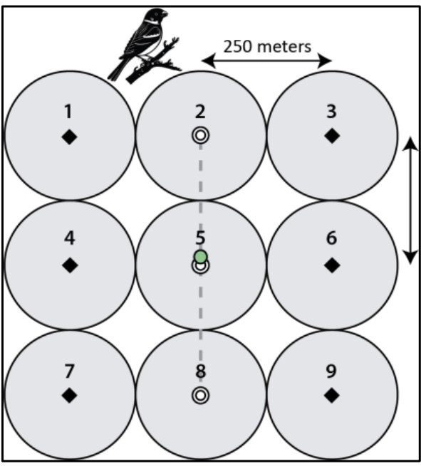

Figure 1: Design of a bird grid, consisting of 9 points separated by a minimum of 250 m. Source: National Ecological Observatory Network, CC-BY (NEON)

More details on NEON’s bird monitoring program are available on the [NEON bird resource page](https://www.neonscience.org/data-collection/birds). Protocols referenced in the data can be found in the [Document Library](https://data.neonscience.org/documents).

# Load libraries

The code examples in this document use R functions provided by the `neonUtilities` package together with `dplyr` for data manipulation. These libraries allow automated download and processing of NEON data products to prepare them for mapping to Darwin Core and the Humboldt Extension.

```r
library(neonUtilities)
library(dplyr)
library(stringr)
library(httr2)
library(purrr)
library(tibble)
```

# Download Data

The data used in this example come from one NEON data products: Breeding landbird point counts. This workflow uses data from **RELEASE-2026**.

- [NEON 2026] NEON (National Ecological Observatory Network) [1]. 2026. Breeding landbird point counts (DP1.10003.001), RELEASE-2026. https://doi.org/10.48443/v6hs-mx57. Dataset accessed from [NEON Data Portal](https://data.neonscience.org/data-products/DP1.10003.001/RELEASE-2026) on 2026-09-14.

A NEON token was used to download the original data for this workflow. Tokens are optional but recommended, as they allow authenticated access and help avoid API rate limits when downloading large datasets. Users preparing their own mappings may wish to generate a personal token. For more information, see the [Using an API Token when Accessing NEON Data with neonUtilities tutorial](https://www.neonscience.org/resources/learning-hub/tutorials/neon-api-tokens-tutorial) and the [NEON API token documentation](https://data.neonscience.org/data-api/rate-limiting/#api-tokens).

## Get Bird data

```r
if (!dir.exists("data")) {
  dir.create("data")
}

if (!dir.exists("outputs")) {
  dir.create("outputs")
}

if (!dir.exists("outputs/full")) {
  dir.create("outputs/full")
}

if (!dir.exists("outputs/zipped")) {
  dir.create("outputs/zipped")
}

if (file.exists("data/bird.occurrence.RData")) {
  load("data/bird.occurrence.RData")
} else {

  bird.occurrence <- loadByProduct(dpID="DP1.10003.001",
                                   package = "expanded",
                                   release = "RELEASE-2026",
                                   token = Sys.getenv("NEON_TOKEN"),
                                   check.size = F)

  save(bird.occurrence, file = "data/bird.occurrence.RData")
}
```

# Map Data

NEON provides separate tables for point-count survey metadata (`brd_perpoint`) and the bird counts themselves (`brd_countdata`).

`brd_perpoint` contains fields describing the location, elevation, date and field-crew recorded weather conditions for each point-count survey.

```r
str(bird.occurrence$brd_perpoint)
```

```
## 'data.frame':    27076 obs. of  32 variables:
##  $ uid                       : chr  "30d14ecc-65a8-4e73-bcb3-d5132c153da2" "f97b6fa3-5719-4c0d-9922-1b23ec949911" "6fdac273-77b0-4e30-86d1-f6ff94f92e66" "ff9f059e-46fa-471a-a41d-2ac759881ff0" ...
##  $ namedLocation             : chr  "BART_025.birdGrid.brd" "BART_025.birdGrid.brd" "BART_025.birdGrid.brd" "BART_025.birdGrid.brd" ...
##  $ domainID                  : chr  "D01" "D01" "D01" "D01" ...
##  $ siteID                    : chr  "BART" "BART" "BART" "BART" ...
##  $ plotID                    : chr  "BART_025" "BART_025" "BART_025" "BART_025" ...
##  $ plotType                  : chr  "distributed" "distributed" "distributed" "distributed" ...
##  $ pointID                   : chr  "3" "2" "1" "4" ...
##  $ nlcdClass                 : chr  "evergreenForest" "evergreenForest" "evergreenForest" "evergreenForest" ...
##  $ decimalLatitude           : num  44.1 44.1 44.1 44.1 44.1 ...
##  $ decimalLongitude          : num  -71.3 -71.3 -71.3 -71.3 -71.3 ...
##  $ geodeticDatum             : chr  "WGS84" "WGS84" "WGS84" "WGS84" ...
##  $ coordinateUncertainty     : num  250 250 250 250 250 ...
##  $ elevation                 : num  576 576 576 576 576 ...
##  $ elevationUncertainty      : num  0.3 0.3 0.3 0.3 0.3 0.3 0.3 0.8 0.8 0.8 ...
```

[output cut: 18 more lines]

```r
head(bird.occurrence$brd_perpoint, n=5)
```

```
##                                    uid         namedLocation domainID siteID
## 1 30d14ecc-65a8-4e73-bcb3-d5132c153da2 BART_025.birdGrid.brd      D01   BART
## 2 f97b6fa3-5719-4c0d-9922-1b23ec949911 BART_025.birdGrid.brd      D01   BART
## 3 6fdac273-77b0-4e30-86d1-f6ff94f92e66 BART_025.birdGrid.brd      D01   BART
## 4 ff9f059e-46fa-471a-a41d-2ac759881ff0 BART_025.birdGrid.brd      D01   BART
## 5 e3f73906-fe6f-4f88-a05e-067a567d6516 BART_025.birdGrid.brd      D01   BART
##     plotID    plotType pointID       nlcdClass decimalLatitude decimalLongitude
## 1 BART_025 distributed       3 evergreenForest        44.06015        -71.31548
## 2 BART_025 distributed       2 evergreenForest        44.06015        -71.31548
## 3 BART_025 distributed       1 evergreenForest        44.06015        -71.31548
## 4 BART_025 distributed       4 evergreenForest        44.06015        -71.31548
## 5 BART_025 distributed       5 evergreenForest        44.06015        -71.31548
##   geodeticDatum coordinateUncertainty elevation elevationUncertainty
## 1         WGS84                 250.3     575.8                  0.3
## 2         WGS84                 250.3     575.8                  0.3
```

[output cut: 33 more lines]

`brd_countdata` contains data for the birds observed during each point-count survey, including identification, observation method, distance, and observed minute.

```r
str(bird.occurrence$brd_countdata)
```

```
## 'data.frame':    373518 obs. of  28 variables:
##  $ uid                    : chr  "08b95360-854d-4d74-a276-93fc7d2423ca" "f2d2d4ce-c978-46a5-befb-4d3b749b1cdb" "754c7b57-1892-4f1f-9f49-594c40d47bfa" "6212a830-6d2d-4999-b169-19273526790e" ...
##  $ namedLocation          : chr  "BART_025.birdGrid.brd" "BART_025.birdGrid.brd" "BART_025.birdGrid.brd" "BART_025.birdGrid.brd" ...
##  $ domainID               : chr  "D01" "D01" "D01" "D01" ...
##  $ siteID                 : chr  "BART" "BART" "BART" "BART" ...
##  $ plotID                 : chr  "BART_025" "BART_025" "BART_025" "BART_025" ...
##  $ plotType               : chr  "distributed" "distributed" "distributed" "distributed" ...
##  $ pointID                : chr  "3" "3" "3" "3" ...
##  $ startDate              : POSIXct, format: "2015-06-14 09:23:00" "2015-06-14 09:23:00" ...
##  $ boutNumber             : int  1 1 1 1 1 1 1 1 1 1 ...
##  $ eventID                : chr  "BRD.BART.2015.1" "BRD.BART.2015.1" "BRD.BART.2015.1" "BRD.BART.2015.1" ...
##  $ pointCountMinute       : int  1 1 2 2 1 3 4 1 1 6 ...
##  $ targetTaxaPresent      : chr  "Y" "Y" "Y" "Y" ...
##  $ taxonID                : chr  "REVI" "BTNW" "BTNW" "BAWW" ...
##  $ scientificName         : chr  "Vireo olivaceus" "Setophaga virens" "Setophaga virens" "Mniotilta varia" ...
##  $ taxonRank              : chr  "species" "species" "species" "species" ...
##  $ vernacularName         : chr  "Red-eyed Vireo" "Black-throated Green Warbler" "Black-throated Green Warbler" "Black-and-white Warbler" ...
##  $ family                 : chr  "Vireonidae" "Parulidae" "Parulidae" "Parulidae" ...
##  $ nativeStatusCode       : chr  "N" "N" "N" "N" ...
##  $ observerDistance       : num  9 12 50 17 42 27 62 26 21 46 ...
##  $ detectionMethod        : chr  "singing" "singing" "singing" "singing" ...
##  $ visualConfirmation     : chr  "No" "No" "No" "No" ...
##  $ sexOrAge               : chr  "Male" "Male" "Male" "Male" ...
##  $ clusterSize            : int  1 1 1 1 1 1 1 1 1 1 ...
##  $ clusterCode            : chr  NA NA NA NA ...
##  $ identifiedBy           : chr  "JRUEB" "JRUEB" "JRUEB" "JRUEB" ...
##  $ identificationHistoryID: chr  NA NA NA NA ...
##  $ publicationDate        : chr  "20260106T223419Z" "20260106T223419Z" "20260106T223419Z" "20260106T223419Z" ...
##  $ release                : chr  "RELEASE-2026" "RELEASE-2026" "RELEASE-2026" "RELEASE-2026" ...
```

```r
head(bird.occurrence$brd_countdata, n=5)
```

```
##                                    uid         namedLocation domainID siteID
## 1 08b95360-854d-4d74-a276-93fc7d2423ca BART_025.birdGrid.brd      D01   BART
## 2 f2d2d4ce-c978-46a5-befb-4d3b749b1cdb BART_025.birdGrid.brd      D01   BART
## 3 754c7b57-1892-4f1f-9f49-594c40d47bfa BART_025.birdGrid.brd      D01   BART
## 4 6212a830-6d2d-4999-b169-19273526790e BART_025.birdGrid.brd      D01   BART
## 5 192585ee-0a3d-4994-856f-3da8090a37c3 BART_025.birdGrid.brd      D01   BART
##     plotID    plotType pointID           startDate boutNumber         eventID
## 1 BART_025 distributed       3 2015-06-14 09:23:00          1 BRD.BART.2015.1
## 2 BART_025 distributed       3 2015-06-14 09:23:00          1 BRD.BART.2015.1
## 3 BART_025 distributed       3 2015-06-14 09:23:00          1 BRD.BART.2015.1
## 4 BART_025 distributed       3 2015-06-14 09:23:00          1 BRD.BART.2015.1
## 5 BART_025 distributed       3 2015-06-14 09:23:00          1 BRD.BART.2015.1
##   pointCountMinute targetTaxaPresent taxonID       scientificName taxonRank
## 1                1                 Y    REVI      Vireo olivaceus   species
## 2                1                 Y    BTNW     Setophaga virens   species
```

[output cut: 21 more lines]

## Preparing the Data

### Create unique IDs

Each point-count survey needs a unique identifier so that we can match each point-count survey record (brd_perpoint) to its corresponding bird data (brd_countdata). We extract the survey year from eventID and then combine the site, plot, point, year, and bout into a single key called pointSurveyID for each of the tables. Note, because the siteID is already included in the plotID (e.g., BART_012), siteID is not actually included in the construction of `pointSurveyID`.

```r
#add pointLocationIDs
bird.occurrence$brd_perpoint <- bird.occurrence$brd_perpoint %>%
  mutate(year = str_extract(eventID, "\\d{4}")) %>%
  mutate(pointLocationID = paste(plotID, "point", pointID, sep = "_"))

bird.occurrence$brd_countdata <- bird.occurrence$brd_countdata %>%
  mutate(year = str_extract(eventID, "\\d{4}")) %>%
  mutate(pointLocationID = paste(plotID, "point", pointID, sep = "_"))

#add pointSurveyIDs
bird.occurrence$brd_perpoint <- bird.occurrence$brd_perpoint %>%
  mutate(year = str_extract(eventID, "\\d{4}")) %>%
  mutate(pointSurveyID = paste(plotID, "point", pointID, year, "bout", boutNumber, sep = "_"))

bird.occurrence$brd_countdata <- bird.occurrence$brd_countdata %>%
  mutate(year = str_extract(eventID, "\\d{4}")) %>%
  mutate(pointSurveyID = paste(plotID, "point", pointID, year, "bout", boutNumber, sep = "_"))
```

### Create date column

```r
bird.occurrence$brd_perpoint$eventDate <- as.Date(
  bird.occurrence$brd_perpoint$startDate
)

bird.occurrence$brd_countdata$eventDate <- as.Date(
  bird.occurrence$brd_countdata$startDate
)
```

## Map Event Core & Humboldt Data

The event hierarchy presented here follows the structure of NEON’s sampling design, with events defined at project, domain, site, plot, point, and individual sampling event (point-count survey) levels. Some event-level information is not provided directly in the NEON data download, such as details describing the overall project, individual domains, and sites. To capture the full hierarchy of the sampling design, these additional levels are reconstructed and included in the event table. The values are hard-coded based on latest (2025-09-24) NEON information.

Domain-level metadata was compiled from NEON documentation and geospatial files. A polygon shapefile defining NEON’s domain boundaries was downloaded from NEONDomains_2024.zip (last updated October 2024, CRS: Geographic WGS 84). Domain centroids (latitude and longitude) and associated uncertainty values were calculated from this shapefile using ArcGIS.

Site-level metadata was retrieved directly from NEON’s public API on September 24, 2025 using the field site metadata download (*NEON_Field_Site_Metadata_20250924*). This download represents a flattened subset of the full JSON objects returned by the [locations/sites API endpoint](https://data.neonscience.org/api/v0/locations/sites).

All fields from the [survey event table template](https://github.com/gbif/doc-guide-publishing-survey-data/tree/1.1_postCommReview/data/event_template_wHE_event-table.csv) are retained for completeness, even when particular values are not applicable for this dataset.

### Project Event

The project event describes the overall bird monitoring program within NEON. It defines the scope of the survey (taxonomic, geographic, temporal), the general sampling protocols, and whether absence, abundance, and material samples are reported. The data for the Event Core and Humboldt extension are split into two separate files.

Mapping Event core fields for the project event level:

```r
NEON_project_event_core <- data.frame(eventID = "NEON",
                                      parentEventID = NA,
                                      fieldNumber = NA,
                                      habitat = NA,
                                      locationID = NA,
                                      countryCode = "US",
                                      decimalLatitude = NA,
                                      decimalLongitude = NA,
                                      coordinateUncertaintyInMeters = NA,
                                      geodeticDatum = NA,
                                      locality = NA,
                                      sampleSizeValue = NA,
                                      sampleSizeUnit = NA,
                                      footprintWKT = NA,
                                      footprintSRS = NA,
                                      eventDate = paste(
                                        min(bird.occurrence$brd_perpoint$eventDate, na.rm = TRUE),
                                        max(bird.occurrence$brd_perpoint$eventDate, na.rm = TRUE),
                                        sep = "/"
                                      ),
                                      eventTime = NA,
                                      eventType = "project",
                                      samplingProtocol = "Point-count Survey",
                                      dataGeneralizations = NA,
                                      informationWithheld = NA,
                                      fieldNotes = NA,
                                      eventRemarks = NA,
                                      identifiedBy = NA
                                    )
```

Mapping Humboldt extension fields for the project event level:

```r
NEON_project_event_humboldt <- data.frame(eventID = "NEON",
                                          siteNestingDescription = "Terrestrial field sites with breeding landbird point-count locations surveyed during standardized six-minute surveys. Large sites contain 5–10 plots, each with a 3x3 grid of nine points spaced 250 m apart and surveyed once per year; small sites contain 2–25 randomly distributed point-count locations spaced at least 250 m apart and surveyed twice per year.",
                                          siteCount = length(unique(bird.occurrence$brd_perpoint$pointLocationID)),
                                          verbatimSiteNames = paste(sort(unique(bird.occurrence$brd_perpoint$pointLocationID)), collapse = " | "),
                                          verbatimSiteDescriptions = NA,
                                          reportedWeather = NA,
                                          reportedExtremeConditions = NA,
                                          totalAreaSampledValue = NA,
                                          totalAreaSampledUnit = NA,
                                          geospatialScopeAreaValue = 9428288, #full geographic extent of USA-NEON boundaries
                                          geospatialScopeAreaUnit = "km²",
                                          isVegetationCoverReported = "false",
                                          eventDurationValue = NA,
                                          eventDurationUnit = NA,
                                          inventoryTypes = NA,
                                          compilationTypes = NA,
                                          compilationSourceTypes = NA,
                                          protocolNames = "Point-count Survey",
                                          protocolDescriptions = "Breeding landbirds are surveyed during standardized six-minute point counts conducted during the breeding season. Field crews visit designated point-count locations and record all birds seen or heard, including taxonomic identification and detection method. Large sites contain 3 x 3 grids of nine points spaced 250 m apart and are surveyed once per year, while small sites contain randomly distributed points spaced at least 250 m apart and are surveyed twice per year.",
                                          protocolReferences = "Esposito, R. 2024. TOS Protocol and Procedure: BRD – Breeding Landbird Abundance and Diversity. NEON.DOC.014041. NEON (National Ecological Observatory Network).",
                                          isAbsenceReported = NA,
                                          absentTaxa = NA,
                                          isAbundanceReported = "true",
                                          isAbundanceCapReported = "false",
                                          abundanceCap = NA,
                                          hasMaterialSamples = "false",
                                          materialSampleTypes = NA,
                                          hasVouchers = "false",
                                          voucherInstitutions = NA,
                                          isLeastSpecificTargetCategoryQuantityInclusive = "false",
                                          verbatimTargetScope = "birds",
                                          targetTaxonomicScope = "Aves",
                                          excludedTaxonomicScope = NA,
                                          isTaxonomicScopeFullyReported = "true",
                                          taxonCompletenessReported = "notReported",
                                          taxonCompletenessProtocols = "Standardized point-count surveys are designed to detect all diurnal terrestrial breeding landbird species seen or heard during the survey period.",
                                          hasNonTargetTaxa = "false",
                                          areNonTargetTaxaFullyReported = NA,
                                          nonTargetTaxa = NA,
                                          targetLifeStageScope = "adult | juvenile",
                                          excludedLifeStageScope = "egg | nestling",
                                          isLifeStageScopeFullyReported = "true",
                                          targetDegreeOfEstablishmentScope = NA,
                                          excludedDegreeOfEstablishmentScope = NA,
                                          isDegreeOfEstablishmentScopeFullyReported = NA,
                                          targetGrowthFormScope = NA,
                                          excludedGrowthFormScope = NA,
                                          isGrowthFormScopeFullyReported = NA,
                                          hasNonTargetOrganisms = NA,
                                          targetHabitatScope = NA,
                                          excludedHabitatScope = NA,
                                          samplingEffort = "6-minute point count per survey location",
                                          isSamplingEffortReported = "true",
                                          samplingEffortProtocol = "Birds are surveyed using standardized 6-minute point counts at each sampling location. Field crews record all birds seen or heard during the survey. Large sites contain 5–10 plots with nine points per grid and are surveyed once annually, while small sites contain 2–25 point-count locations and are surveyed twice annually.",
                                          samplingEffortValue = "6",
                                          samplingEffortUnit = "minutes per point-count survey",
                                          samplingPerformedBy = "NEON Field Staff"
                                        )
```

### Domain Events

Domains represent NEON’s ecoclimatic regions. Each domain includes one or more terrestrial sites where bird sampling occurs.

Setup:

```r
NEON_domain_metadata <- read.csv("data/NEON_Domain_Metadata_20250924.csv", stringsAsFactors = FALSE)

NEON_domain_list <- unique(bird.occurrence$brd_perpoint[, c("domainID")])

#index
domain_idx <- match(NEON_domain_list, NEON_domain_metadata$domain_id)
```

Mapping Event core fields for the domain event level:

```r
added_domain_data_core <- data.frame(eventID = NEON_domain_metadata$domain_id[domain_idx],
                                      parentEventID = "NEON",
                                      fieldNumber = NA,
                                      habitat = NA,
                                      locationID = NEON_domain_metadata$domain_id[domain_idx],
                                      countryCode = "US",
                                      decimalLatitude = NEON_domain_metadata$decimalLatitude[domain_idx],
                                      decimalLongitude = NEON_domain_metadata$decimalLongitude[domain_idx],
                                      coordinateUncertaintyInMeters = NEON_domain_metadata$coordinateUncertaintyinMeters[domain_idx],
                                      geodeticDatum = "WGS84",
                                      locality = paste(NEON_domain_metadata$domain_name[domain_idx], " (", NEON_domain_metadata$domain_id[domain_idx], ")", sep = ""),
                                      sampleSizeValue = NA,
                                      sampleSizeUnit = NA,
                                      footprintWKT = NA,
                                      footprintSRS = NA,
                                      eventDate = tapply(
                                        bird.occurrence$brd_perpoint$eventDate,
                                        bird.occurrence$brd_perpoint$domainID,
                                        function(x) paste(min(x, na.rm = TRUE), max(x, na.rm = TRUE), sep = "/")
                                      )[NEON_domain_list],
                                      eventTime = NA,
                                      eventType = "survey", #eventType describes the event, not the internal vocabulary
                                      samplingProtocol = "Point-count Survey",
                                      dataGeneralizations = NA,
                                      informationWithheld = NA,
                                      fieldNotes = NA,
                                      eventRemarks = NA,
                                      identifiedBy = bird.occurrence$brd_countdata %>%
                                        group_by(domainID) %>%
                                        summarise(
                                          identifiedBy = paste(sort(unique(identifiedBy)), collapse = " | "),
                                          .groups = "drop"
                                        ) %>%
                                        right_join(data.frame(domainID = NEON_domain_list), by = "domainID") %>%
                                        arrange(match(domainID, NEON_domain_list)) %>%
                                        mutate(identifiedBy = ifelse(is.na(identifiedBy), NA, identifiedBy)) %>%
                                        pull(identifiedBy)
                                    )
```

Mapping Humboldt extension fields for the domain event level:

```r
added_domain_data_humboldt <- data.frame(eventID = NEON_domain_metadata$domain_id[domain_idx],
                                          siteNestingDescription = "Each domain contains terrestrial field sites with plots containing designated point-count locations for breeding landbird surveys",
                                          siteCount = tapply(bird.occurrence$brd_perpoint$plotID,
                                                             bird.occurrence$brd_perpoint$domainID,
                                                             function(x) length(unique(x)))[NEON_domain_list],
                                          verbatimSiteNames = tapply(bird.occurrence$brd_perpoint$plotID,
                                                                     bird.occurrence$brd_perpoint$domainID,
                                                                     function(x) paste(sort(unique(x)), collapse = " | ")
                                                                   )[NEON_domain_list],
                                          verbatimSiteDescriptions = NA,
                                          reportedWeather = NA,
                                          reportedExtremeConditions = NA,
                                          totalAreaSampledValue = NA,
                                          totalAreaSampledUnit = NA,
                                          geospatialScopeAreaValue = NEON_domain_metadata$sq_km[domain_idx],
                                          geospatialScopeAreaUnit = "km²",
                                          isVegetationCoverReported = "false",
                                          eventDurationValue = NA,
                                          eventDurationUnit = NA,
                                          inventoryTypes = NA,
                                          compilationTypes = NA,
                                          compilationSourceTypes = NA,
                                          protocolNames = "Point-count Survey",
                                          protocolDescriptions = "Breeding landbirds are surveyed during standardized six-minute point counts conducted during the breeding season. Field crews visit designated point-count locations and record all birds seen or heard, including taxonomic identification and detection method. Large sites contain 3 x 3 grids of nine points spaced 250 m apart and are surveyed once per year, while small sites contain randomly distributed points spaced at least 250 m apart and are surveyed twice per year.",
                                          protocolReferences = "Esposito, R. 2024. TOS Protocol and Procedure: BRD – Breeding Landbird Abundance and Diversity. NEON.DOC.014041. NEON (National Ecological Observatory Network).",
                                          isAbsenceReported = NA,
                                          absentTaxa = NA,
                                          isAbundanceReported = "true",
                                          isAbundanceCapReported = "false",
                                          abundanceCap = NA,
                                          hasMaterialSamples = "false",
                                          materialSampleTypes = NA,
                                          hasVouchers = "false",
                                          voucherInstitutions = NA,
                                          isLeastSpecificTargetCategoryQuantityInclusive = "false",
                                          verbatimTargetScope = "birds",
                                          targetTaxonomicScope = "Aves",
                                          excludedTaxonomicScope = NA,
                                          isTaxonomicScopeFullyReported = "true",
                                          taxonCompletenessReported = "notReported",
                                          taxonCompletenessProtocols = "Standardized point-count surveys are designed to detect all diurnal terrestrial breeding landbird species seen or heard during the survey period.",
                                          hasNonTargetTaxa = "false",
                                          areNonTargetTaxaFullyReported = NA,
                                          nonTargetTaxa = NA,
                                          targetLifeStageScope = "adult | juvenile",
                                          excludedLifeStageScope = "egg | nestling",
                                          isLifeStageScopeFullyReported = "true",
                                          targetDegreeOfEstablishmentScope = NA,
                                          excludedDegreeOfEstablishmentScope = NA,
                                          isDegreeOfEstablishmentScopeFullyReported = NA,
                                          targetGrowthFormScope = NA,
                                          excludedGrowthFormScope = NA,
                                          isGrowthFormScopeFullyReported = NA,
                                          hasNonTargetOrganisms = NA,
                                          targetHabitatScope = NA,
                                          excludedHabitatScope = NA,
                                          samplingEffort = "6-minute point count per survey location",
                                          isSamplingEffortReported = "true",
                                          samplingEffortProtocol = "Birds are surveyed using standardized 6-minute point counts at each sampling location. Field crews record all birds seen or heard during the survey. Large sites contain 5–10 plots with nine points per grid and are surveyed once annually, while small sites contain 2–25 point-count locations and are surveyed twice annually.",
                                          samplingEffortValue = "6",
                                          samplingEffortUnit = "minutes per point-count survey",
                                          samplingPerformedBy = tapply(
                                            bird.occurrence$brd_perpoint$measuredBy,
                                            bird.occurrence$brd_perpoint$domainID,
                                            function(x) paste(sort(unique(x)), collapse = " | ")
                                          )[NEON_domain_metadata$domain_id]
                                        )
```

### Site Events

Each NEON terrestrial site contains designated locations for breeding landbird point-count surveys. Large sites contain 5–10 plots, each with a 3×3 grid of nine points spaced 250 m apart, while small sites contain 2–25 randomly distributed point-count locations spaced at least 250 m apart. Site events record location metadata, habitat information, and elevation.

Setup:

```r
NEON_site_metadata <- read.csv(
  "https://www.neonscience.org/field-sites/exports/NEON_Field_Site_Metadata_20250924",
  stringsAsFactors = FALSE
)

NEON_site_list <- unique(bird.occurrence$brd_perpoint[, c("siteID")])

#indexes
site_idx <- match(NEON_site_list, NEON_site_metadata$site_id)
```

Mapping Event core fields for the site event level:

```r
added_site_data_core <- data.frame(eventID = NEON_site_metadata$site_id[site_idx],
                                    parentEventID = NEON_site_metadata$domain_id[site_idx],
                                    fieldNumber = NA,
                                    habitat = gsub("\\|", " | ", NEON_site_metadata$dominant_nlcd_classes[site_idx]),
                                    locationID = NEON_site_metadata$site_id[site_idx],
                                    countryCode = "US",
                                    county = NEON_site_metadata$site_county[site_idx],
                                    stateProvince = NEON_site_metadata$site_state[site_idx],
                                    decimalLatitude = NEON_site_metadata$latitude[site_idx],
                                    decimalLongitude = NEON_site_metadata$longitude[site_idx],
                                    coordinateUncertaintyInMeters = NA,
                                    geodeticDatum = "WGS84",
                                    locality = paste(NEON_site_metadata$site_name[site_idx], " (", NEON_site_metadata$site_id[site_idx], ")", sep = ""),
                                    minimumElevationInMeters = NEON_site_metadata$minimum_elevation_m[site_idx],
                                    maximumElevationInMeters = NEON_site_metadata$maximum_elevation_m[site_idx],
                                    verbatimElevation = paste(NEON_site_metadata$mean_evelation_m[site_idx], "m", sep=""),
                                    sampleSizeValue = NA,
                                    sampleSizeUnit = NA,
                                    footprintWKT = NA,
                                    footprintSRS = NA,
                                    eventDate = tapply(
                                      bird.occurrence$brd_perpoint$eventDate,
                                      bird.occurrence$brd_perpoint$siteID,
                                      function(x) paste(min(x, na.rm = TRUE), max(x, na.rm = TRUE), sep = "/")
                                    )[NEON_site_list],
                                    eventTime = NA,
                                    eventType = "survey",
                                    samplingProtocol = "Point-count Survey",
                                    dataGeneralizations = NA,
                                    informationWithheld = NA,
                                    fieldNotes = NA,
                                    eventRemarks = NA,
                                    identifiedBy = bird.occurrence$brd_countdata %>%
                                      group_by(siteID) %>%
                                      summarise(
                                        identifiedBy = paste(sort(unique(identifiedBy)), collapse = " | "),
                                        .groups = "drop"
                                      ) %>%
                                      right_join(data.frame(siteID = NEON_site_list), by = "siteID") %>%
                                      arrange(match(siteID, NEON_site_list)) %>%
                                      mutate(identifiedBy = ifelse(is.na(identifiedBy), NA, identifiedBy)) %>%
                                      pull(identifiedBy)
                                  )
```

Mapping Humboldt extension fields for the site event level:

```r
added_site_data_humboldt <- data.frame(eventID = NEON_site_metadata$site_id[site_idx],
                                        siteNestingDescription = "Each domain contains terrestrial field sites with plots containing designated point-count locations for breeding landbird surveys",
                                        siteCount = tapply(bird.occurrence$brd_perpoint$plotID,
                                                           bird.occurrence$brd_perpoint$siteID,
                                                           function(x) length(unique(x)))[NEON_site_list],
                                        verbatimSiteNames = tapply(bird.occurrence$brd_perpoint$plotID,
                                                                   bird.occurrence$brd_perpoint$siteID,
                                                                   function(x) paste(sort(unique(x)), collapse = " | ")
                                                                 )[NEON_site_list],
                                        verbatimSiteDescriptions = NEON_site_metadata$site_type[site_idx],
                                        reportedWeather = NA,
                                        reportedExtremeConditions = NA,
                                        totalAreaSampledValue = NA,
                                        totalAreaSampledUnit = NA,
                                        geospatialScopeAreaValue = NEON_site_metadata$terrestrial_sampling_boundary_size_km2[site_idx],
                                        geospatialScopeAreaUnit = "km²",
                                        isVegetationCoverReported = "false",
                                        eventDurationValue = NA,
                                        eventDurationUnit = NA,
                                        inventoryTypes = NA,
                                        compilationTypes = NA,
                                        compilationSourceTypes = NA,
                                        protocolNames = "Point-count Survey",
                                        protocolDescriptions = "Breeding landbirds are surveyed during standardized six-minute point counts conducted during the breeding season. Field crews visit designated point-count locations and record all birds seen or heard, including taxonomic identification and detection method. Large sites contain 3 x 3 grids of nine points spaced 250 m apart and are surveyed once per year, while small sites contain randomly distributed points spaced at least 250 m apart and are surveyed twice per year.",
                                        protocolReferences = "Esposito, R. 2024. TOS Protocol and Procedure: BRD – Breeding Landbird Abundance and Diversity. NEON.DOC.014041. NEON (National Ecological Observatory Network).",
                                        isAbsenceReported = NA,
                                        absentTaxa = NA,
                                        isAbundanceReported = "true",
                                        isAbundanceCapReported = "false",
                                        abundanceCap = NA,
                                        hasMaterialSamples = "false",
                                        materialSampleTypes = NA,
                                        hasVouchers = "false",
                                        voucherInstitutions = NA,
                                        isLeastSpecificTargetCategoryQuantityInclusive = "false",
                                        verbatimTargetScope = "birds",
                                        targetTaxonomicScope = "Aves",
                                        excludedTaxonomicScope = NA,
                                        isTaxonomicScopeFullyReported = "true",
                                        taxonCompletenessReported = "notReported",
                                        taxonCompletenessProtocols = "Standardized point-count surveys are designed to detect all diurnal terrestrial breeding landbird species seen or heard during the survey period.",
                                        hasNonTargetTaxa = "false",
                                        areNonTargetTaxaFullyReported = NA,
                                        nonTargetTaxa = NA,
                                        targetLifeStageScope = "adult | juvenile",
                                        excludedLifeStageScope = "egg | nestling",
                                        isLifeStageScopeFullyReported = "true",
                                        targetDegreeOfEstablishmentScope = NA,
                                        excludedDegreeOfEstablishmentScope = NA,
                                        isDegreeOfEstablishmentScopeFullyReported = NA,
                                        targetGrowthFormScope = NA,
                                        excludedGrowthFormScope = NA,
                                        isGrowthFormScopeFullyReported = NA,
                                        hasNonTargetOrganisms = NA,
                                        targetHabitatScope = NA,
                                        excludedHabitatScope = NA,
                                        samplingEffort = "6-minute point count per survey location",
                                        isSamplingEffortReported = "true",
                                        samplingEffortProtocol = "Birds are surveyed using standardized 6-minute point counts at each sampling location. Field crews record all birds seen or heard during the survey. Large sites contain 5–10 plots with nine points per grid and are surveyed once annually, while small sites contain 2–25 point-count locations and are surveyed twice annually.",
                                        samplingEffortValue = "6",
                                        samplingEffortUnit = "minutes per point-count survey",
                                        samplingPerformedBy = bird.occurrence$brd_perpoint %>%
                                          group_by(siteID) %>%
                                          summarise(
                                            samplingPerformedBy = paste(
                                              sort(unique(measuredBy[!is.na(measuredBy)])),
                                              collapse = " | "
                                            ),
                                            .groups = "drop"
                                          ) %>%
                                          right_join(data.frame(siteID = NEON_site_list), by = "siteID") %>%
                                          arrange(match(siteID, NEON_site_list)) %>%
                                          mutate(
                                            samplingPerformedBy = ifelse(
                                              samplingPerformedBy == "",
                                              NA,
                                              samplingPerformedBy
                                            )
                                          ) %>%
                                          pull(samplingPerformedBy)
                                      )
```

### Plot Events

Plot events represent spatial sampling units within NEON’s breeding landbird monitoring design. At large sites, each plot contains a 3×3 grid of nine point-count locations spaced 250 m apart. At small sites, plots contain a single point-count location. Plot-level metadata include plot identifiers, habitat information, and elevation.

Setup:

```r
NEON_plot_metadata <- unique(bird.occurrence$brd_perpoint[, c("namedLocation",
                                                               "siteID",
                                                               "plotID",
                                                               "plotType",
                                                               "nlcdClass",
                                                               "decimalLatitude",
                                                               "decimalLongitude",
                                                               "geodeticDatum",
                                                               "coordinateUncertainty",
                                                               "elevation",
                                                               "elevationUncertainty")])
```

Mapping Event core fields for the plot event level:

```r
added_plot_data_core <- data.frame(eventID = NEON_plot_metadata$plotID,
                                    parentEventID = NEON_plot_metadata$siteID,
                                    fieldNumber = NA,
                                    habitat = NEON_plot_metadata$nlcdClass,
                                    locationID = NEON_plot_metadata$plotID,
                                    countryCode = "US",
                                    decimalLatitude = NEON_plot_metadata$decimalLatitude,
                                    decimalLongitude = NEON_plot_metadata$decimalLongitude,
                                    coordinateUncertaintyInMeters = NEON_plot_metadata$coordinateUncertainty,
                                    geodeticDatum = "WGS84",
                                    locality = NEON_plot_metadata$plotID,
                                    minimumElevationInMeters = NEON_plot_metadata$elevation - NEON_plot_metadata$elevationUncertainty,
                                    maximumElevationInMeters = NEON_plot_metadata$elevation + NEON_plot_metadata$elevationUncertainty,
                                    verbatimElevation = paste(NEON_plot_metadata$elevation, "m", sep=""),
                                    sampleSizeValue = NA,
                                    sampleSizeUnit = NA,
                                    footprintWKT = NA,
                                    footprintSRS = NA,
                                    eventDate = tapply(
                                      bird.occurrence$brd_perpoint$eventDate,
                                      bird.occurrence$brd_perpoint$plotID,
                                      function(x) paste(min(x, na.rm = TRUE), max(x, na.rm = TRUE), sep = "/")
                                    )[NEON_plot_metadata$plotID],
                                    eventTime = NA,
                                    eventType = "survey",
                                    samplingProtocol = "Point-count Survey",
                                    dataGeneralizations = NA,
                                    informationWithheld = NA,
                                    fieldNotes = NA,
                                    eventRemarks = NA,
                                    identifiedBy = tapply(
                                      bird.occurrence$brd_countdata$identifiedBy,
                                      bird.occurrence$brd_countdata$plotID,
                                      function(x) paste(sort(unique(x)), collapse = " | ")
                                    )[NEON_plot_metadata$plotID]
                                  )
```

Mapping Humboldt extension fields for the plot event level:

```r
added_plot_data_humboldt <- data.frame(eventID = NEON_plot_metadata$plotID,
                                        siteNestingDescription = "One plot containing designated breeding landbird point-count locations",
                                        siteCount = 1,
                                        verbatimSiteNames = NEON_plot_metadata$plotID,
                                        verbatimSiteDescriptions = NA,
                                        reportedWeather = NA,
                                        reportedExtremeConditions = NA,
                                        totalAreaSampledValue = NA,
                                        totalAreaSampledUnit = NA,
                                        geospatialScopeAreaValue = NA,
                                        geospatialScopeAreaUnit = NA,
                                        isVegetationCoverReported = "false",
                                        eventDurationValue = NA,
                                        eventDurationUnit = NA,
                                        inventoryTypes = NA,
                                        compilationTypes = NA,
                                        compilationSourceTypes = NA,
                                        protocolNames = "Point-count Survey",
                                        protocolDescriptions = "Breeding landbirds are surveyed during standardized six-minute point counts conducted during the breeding season. Field crews visit designated point-count locations and record all birds seen or heard, including taxonomic identification and detection method. Large sites contain 3 x 3 grids of nine points spaced 250 m apart and are surveyed once per year, while small sites contain randomly distributed points spaced at least 250 m apart and are surveyed twice per year.",
                                        protocolReferences = "Esposito, R. 2024. TOS Protocol and Procedure: BRD – Breeding Landbird Abundance and Diversity. NEON.DOC.014041. NEON (National Ecological Observatory Network).",
                                        isAbsenceReported = NA,
                                        absentTaxa = NA,
                                        isAbundanceReported = "true",
                                        isAbundanceCapReported = "false",
                                        abundanceCap = NA,
                                        hasMaterialSamples = "false",
                                        materialSampleTypes = NA,
                                        hasVouchers = "false",
                                        voucherInstitutions = NA,
                                        isLeastSpecificTargetCategoryQuantityInclusive = "false",
                                        verbatimTargetScope = "birds",
                                        targetTaxonomicScope = "Aves",
                                        excludedTaxonomicScope = NA,
                                        isTaxonomicScopeFullyReported = "true",
                                        taxonCompletenessReported = "notReported",
                                        taxonCompletenessProtocols = "Standardized point-count surveys are designed to detect all diurnal terrestrial breeding landbird species seen or heard during the survey period.",
                                        hasNonTargetTaxa = "false",
                                        areNonTargetTaxaFullyReported = NA,
                                        nonTargetTaxa = NA,
                                        targetLifeStageScope = "adult | juvenile",
                                        excludedLifeStageScope = "egg | nestling",
                                        isLifeStageScopeFullyReported = "true",
                                        targetDegreeOfEstablishmentScope = NA,
                                        excludedDegreeOfEstablishmentScope = NA,
                                        isDegreeOfEstablishmentScopeFullyReported = NA,
                                        targetGrowthFormScope = NA,
                                        excludedGrowthFormScope = NA,
                                        isGrowthFormScopeFullyReported = NA,
                                        hasNonTargetOrganisms = NA,
                                        targetHabitatScope = NA,
                                        excludedHabitatScope = NA,
                                        samplingEffort = "6-minute point count per survey location",
                                        isSamplingEffortReported = "true",
                                        samplingEffortProtocol = "Birds are surveyed using standardized 6-minute point counts at each sampling location. Field crews record all birds seen or heard during the survey. Large sites contain 5–10 plots with nine points per grid and are surveyed once annually, while small sites contain 2–25 point-count locations and are surveyed twice annually.",
                                        samplingEffortValue = "6",
                                        samplingEffortUnit = "minutes per point-count survey",
                                        samplingPerformedBy = tapply(
                                          bird.occurrence$brd_perpoint$measuredBy,
                                          bird.occurrence$brd_perpoint$plotID,
                                          function(x) paste(sort(unique(x)), collapse = " | ")
                                        )[NEON_plot_metadata$plotID]
                                      )
```

### Point Events

Point events represent the smallest sampling units within NEON’s breeding landbird monitoring design. At large sites, each plot contains a 3×3 grid of nine point-count locations spaced 250 m apart. At small sites, plots contain a single point-count location.

Setup:

```r
NEON_point_metadata <- bird.occurrence$brd_perpoint %>%
  group_by(pointLocationID) %>%
  summarise(
    plotID = first(plotID),
    observedHabitat = paste(
      sort(unique(observedHabitat[!is.na(observedHabitat)])),
      collapse = " | "
    ),
    .groups = "drop"
  )
```

Mapping Event core fields for the point event level:

```r
added_point_data_core <- data.frame(eventID = NEON_point_metadata$pointLocationID,
                                    parentEventID = NEON_point_metadata$plotID,
                                    fieldNumber = NA,
                                    habitat = NEON_point_metadata$observedHabitat,
                                    locationID = NEON_point_metadata$pointLocationID,
                                    countryCode = "US",
                                    decimalLatitude = NA,
                                    decimalLongitude = NA,
                                    coordinateUncertaintyInMeters = NA,
                                    geodeticDatum = NA,
                                    locality = NEON_point_metadata$pointLocationID,
                                    minimumElevationInMeters = NA,
                                    maximumElevationInMeters = NA,
                                    verbatimElevation = NA,
                                    sampleSizeValue = NA,
                                    sampleSizeUnit = NA,
                                    footprintWKT = NA,
                                    footprintSRS = NA,
                                    eventDate = tapply(
                                      bird.occurrence$brd_perpoint$eventDate,
                                      bird.occurrence$brd_perpoint$pointLocationID,
                                      function(x) paste(min(x, na.rm = TRUE), max(x, na.rm = TRUE), sep = "/")
                                    )[NEON_point_metadata$pointLocationID],
                                    eventTime = NA,
                                    eventType = "survey",
                                    samplingProtocol = "Point-count Survey",
                                    dataGeneralizations = NA,
                                    informationWithheld = NA,
                                    fieldNotes = NA,
                                    eventRemarks = NA,
                                    identifiedBy = tapply(
                                      bird.occurrence$brd_countdata$identifiedBy,
                                      bird.occurrence$brd_countdata$pointLocationID,
                                      function(x) paste(sort(unique(x)), collapse = " | ")
                                    )[NEON_point_metadata$pointLocationID]
                                  )
```

Mapping Humboldt extension fields for the point event level:

```r
added_point_data_humboldt <- data.frame(eventID = NEON_point_metadata$pointLocationID,
                                        siteNestingDescription = "One designated breeding landbird point-count location",
                                        siteCount = 1,
                                        verbatimSiteNames = NEON_point_metadata$pointLocationID,
                                        verbatimSiteDescriptions = NA,
                                        reportedWeather = NA,
                                        reportedExtremeConditions = NA,
                                        totalAreaSampledValue = NA,
                                        totalAreaSampledUnit = NA,
                                        geospatialScopeAreaValue = NA,
                                        geospatialScopeAreaUnit = NA,
                                        isVegetationCoverReported = "false",
                                        eventDurationValue = NA,
                                        eventDurationUnit = NA,
                                        inventoryTypes = NA,
                                        compilationTypes = NA,
                                        compilationSourceTypes = NA,
                                        protocolNames = "Point-count Survey",
                                        protocolDescriptions = "Breeding landbirds are surveyed during standardized six-minute point counts conducted during the breeding season. Field crews visit designated point-count locations and record all birds seen or heard, including taxonomic identification and detection method. Large sites contain 3 x 3 grids of nine points spaced 250 m apart and are surveyed once per year, while small sites contain randomly distributed points spaced at least 250 m apart and are surveyed twice per year.",
                                        protocolReferences = "Esposito, R. 2024. TOS Protocol and Procedure: BRD – Breeding Landbird Abundance and Diversity. NEON.DOC.014041. NEON (National Ecological Observatory Network).",
                                        isAbsenceReported = NA,
                                        absentTaxa = NA,
                                        isAbundanceReported = "true",
                                        isAbundanceCapReported = "false",
                                        abundanceCap = NA,
                                        hasMaterialSamples = "false",
                                        materialSampleTypes = NA,
                                        hasVouchers = "false",
                                        voucherInstitutions = NA,
                                        isLeastSpecificTargetCategoryQuantityInclusive = "false",
                                        verbatimTargetScope = "birds",
                                        targetTaxonomicScope = "Aves",
                                        excludedTaxonomicScope = NA,
                                        isTaxonomicScopeFullyReported = "true",
                                        taxonCompletenessReported = "notReported",
                                        taxonCompletenessProtocols = "Standardized point-count surveys are designed to detect all diurnal terrestrial breeding landbird species seen or heard during the survey period.",
                                        hasNonTargetTaxa = "false",
                                        areNonTargetTaxaFullyReported = NA,
                                        nonTargetTaxa = NA,
                                        targetLifeStageScope = "adult | juvenile",
                                        excludedLifeStageScope = "egg | nestling",
                                        isLifeStageScopeFullyReported = "true",
                                        targetDegreeOfEstablishmentScope = NA,
                                        excludedDegreeOfEstablishmentScope = NA,
                                        isDegreeOfEstablishmentScopeFullyReported = NA,
                                        targetGrowthFormScope = NA,
                                        excludedGrowthFormScope = NA,
                                        isGrowthFormScopeFullyReported = NA,
                                        hasNonTargetOrganisms = NA,
                                        targetHabitatScope = NA,
                                        excludedHabitatScope = NA,
                                        samplingEffort = "6-minute point count per survey location",
                                        isSamplingEffortReported = "true",
                                        samplingEffortProtocol = "Birds are surveyed using standardized 6-minute point counts at each sampling location. Field crews record all birds seen or heard during the survey. Large sites contain 5–10 plots with nine points per grid and are surveyed once annually, while small sites contain 2–25 point-count locations and are surveyed twice annually.",
                                        samplingEffortValue = "6",
                                        samplingEffortUnit = "minutes per point-count survey",
                                        samplingPerformedBy = tapply(
                                          bird.occurrence$brd_perpoint$measuredBy,
                                          bird.occurrence$brd_perpoint$pointLocationID,
                                          function(x) paste(sort(unique(x)), collapse = " | ")
                                        )[NEON_point_metadata$pointLocationID]
                                      )
```

### Point Visit Events

Point-count visit events describe individual breeding landbird surveys conducted at a designated point. At this level, we record the survey date and time, observer, detection conditions, and other field information. During each standardized six-minute survey, all birds seen or heard are recorded, including detections used to determine presence or nondetection. These events link the hierarchical survey design to the occurrence records derived from individual bird observations.

Mapping Event core fields for the point visit event level:

```r
added_point_visit_data_core <- data.frame(eventID = bird.occurrence$brd_perpoint$pointSurveyID,
                                          parentEventID = bird.occurrence$brd_perpoint$pointLocationID,
                                          fieldNumber = NA,
                                          habitat = bird.occurrence$brd_perpoint$observedHabitat,
                                          locationID = bird.occurrence$brd_perpoint$pointLocationID,
                                          countryCode = "US",
                                          decimalLatitude = bird.occurrence$brd_perpoint$decimalLatitude,
                                          decimalLongitude = bird.occurrence$brd_perpoint$decimalLongitude,
                                          coordinateUncertaintyInMeters = bird.occurrence$brd_perpoint$coordinateUncertainty,
                                          geodeticDatum = "WGS84",
                                          locality = bird.occurrence$brd_perpoint$pointLocationID,
                                          minimumElevationInMeters = bird.occurrence$brd_perpoint$elevation - bird.occurrence$brd_perpoint$elevationUncertainty,
                                          maximumElevationInMeters = bird.occurrence$brd_perpoint$elevation + bird.occurrence$brd_perpoint$elevationUncertainty,
                                          verbatimElevation = paste(bird.occurrence$brd_perpoint$elevation, "m", sep=""),
                                          sampleSizeValue = NA,
                                          sampleSizeUnit = NA,
                                          footprintWKT = NA,
                                          footprintSRS = NA,
                                          eventDate = paste(bird.occurrence$brd_perpoint$eventDate),
                                          eventTime = ifelse(
                                            bird.occurrence$brd_perpoint$samplingImpractical == "OK",
                                            paste0(
                                              format(bird.occurrence$brd_perpoint$startDate, "%H:%M:%S"),
                                              "/",
                                              format(
                                                bird.occurrence$brd_perpoint$startDate + lubridate::minutes(6),
                                                "%H:%M:%S"
                                              )
                                            ),
                                            format(bird.occurrence$brd_perpoint$startDate, "%H:%M:%S")
                                          ),
                                          eventType = "site visit",
                                          samplingProtocol = "Point-count Survey",
                                          dataGeneralizations = NA,
                                          informationWithheld = NA,
                                          fieldNotes = NA,
                                          eventRemarks = bird.occurrence$brd_perpoint$remarks,
                                          identifiedBy = bird.occurrence$brd_perpoint %>%
                                            left_join(
                                              bird.occurrence$brd_countdata %>%
                                                group_by(pointSurveyID) %>%
                                                summarise(
                                                  identifiedBy = paste(sort(unique(identifiedBy)), collapse = " | "),
                                                  .groups = "drop"
                                                ),
                                              by = "pointSurveyID"
                                            ) %>%
                                            pull(identifiedBy)
                                        )
```

Mapping Humboldt extension fields for the point visit event level:

```r
added_point_visit_data_humboldt <- data.frame(eventID = bird.occurrence$brd_perpoint$pointSurveyID,
                                              siteNestingDescription = "One designated breeding landbird point-count location",
                                              siteCount = 1,
                                              verbatimSiteNames = bird.occurrence$brd_perpoint$pointLocationID,
                                              verbatimSiteDescriptions = NA,
                                              reportedWeather = apply(
                                                data.frame(
                                                  cloudStart = ifelse(
                                                    is.na(bird.occurrence$brd_perpoint$startCloudCoverPercentage),
                                                    NA,
                                                    paste0("Cloud cover start: ",
                                                           bird.occurrence$brd_perpoint$startCloudCoverPercentage, "%")
                                                  ),
                                                  cloudEnd = ifelse(
                                                    is.na(bird.occurrence$brd_perpoint$endCloudCoverPercentage),
                                                    NA,
                                                    paste0("Cloud cover end: ",
                                                           bird.occurrence$brd_perpoint$endCloudCoverPercentage, "%")
                                                  ),
                                                  rhStart = ifelse(
                                                    is.na(bird.occurrence$brd_perpoint$startRH),
                                                    NA,
                                                    paste0("Relative humidity start: ",
                                                           bird.occurrence$brd_perpoint$startRH, "%")
                                                  ),
                                                  rhEnd = ifelse(
                                                    is.na(bird.occurrence$brd_perpoint$endRH),
                                                    NA,
                                                    paste0("Relative humidity end: ",
                                                           bird.occurrence$brd_perpoint$endRH, "%")
                                                  ),
                                                  temp = ifelse(
                                                    is.na(bird.occurrence$brd_perpoint$observedAirTemp),
                                                    NA,
                                                    paste0("Air temperature: ",
                                                           bird.occurrence$brd_perpoint$observedAirTemp, " C")
                                                  ),
                                                  wind = ifelse(
                                                    is.na(bird.occurrence$brd_perpoint$kmPerHourObservedWindSpeed),
                                                    NA,
                                                    paste0("Wind speed: ",
                                                           bird.occurrence$brd_perpoint$kmPerHourObservedWindSpeed, " km/h")
                                                  )
                                                ),
                                                1,
                                                function(x) {
                                                  x <- x[!is.na(x)]
                                                  if (length(x) == 0) NA_character_ else paste(x, collapse = "; ")
                                                }
                                              ),
                                              reportedExtremeConditions = ifelse(
                                                is.na(bird.occurrence$brd_perpoint$samplingImpractical) | bird.occurrence$brd_perpoint$samplingImpractical == "OK", NA,
                                                paste0(bird.occurrence$brd_perpoint$samplingImpractical, ", sampling impractical")
                                              ),
                                              totalAreaSampledValue = NA,
                                              totalAreaSampledUnit = NA,
                                              geospatialScopeAreaValue = NA,
                                              geospatialScopeAreaUnit = NA,
                                              isVegetationCoverReported = "false",
                                              eventDurationValue = ifelse(
                                                bird.occurrence$brd_perpoint$samplingImpractical == "OK",
                                                6,
                                                NA
                                              ),
                                              eventDurationUnit = ifelse(
                                                bird.occurrence$brd_perpoint$samplingImpractical == "OK",
                                                "min",
                                                NA
                                              ),
                                              inventoryTypes = NA,
                                              compilationTypes = NA,
                                              compilationSourceTypes = NA,
                                              protocolNames = "Point-count Survey",
                                              protocolDescriptions = "Breeding landbirds are surveyed during standardized six-minute point counts conducted during the breeding season. Field crews visit designated point-count locations and record all birds seen or heard, including taxonomic identification and detection method. Large sites contain 3 x 3 grids of nine points spaced 250 m apart and are surveyed once per year, while small sites contain randomly distributed points spaced at least 250 m apart and are surveyed twice per year.",
                                              protocolReferences = "Esposito, R. 2024. TOS Protocol and Procedure: BRD – Breeding Landbird Abundance and Diversity. NEON.DOC.014041. NEON (National Ecological Observatory Network).",
                                              isAbsenceReported = NA,
                                              absentTaxa = NA,
                                              isAbundanceReported = "true",
                                              isAbundanceCapReported = "false",
                                              abundanceCap = NA,
                                              hasMaterialSamples = "false",
                                              materialSampleTypes = NA,
                                              hasVouchers = "false",
                                              voucherInstitutions = NA,
                                              isLeastSpecificTargetCategoryQuantityInclusive = "false",
                                              verbatimTargetScope = "birds",
                                              targetTaxonomicScope = "Aves",
                                              excludedTaxonomicScope = NA,
                                              isTaxonomicScopeFullyReported = "true",
                                              taxonCompletenessReported = "notReported",
                                              taxonCompletenessProtocols = "Standardized point-count surveys are designed to detect all diurnal terrestrial breeding landbird species seen or heard during the survey period.",
                                              hasNonTargetTaxa = "false",
                                              areNonTargetTaxaFullyReported = NA,
                                              nonTargetTaxa = NA,
                                              targetLifeStageScope = "adult | juvenile",
                                              excludedLifeStageScope = "egg | nestling",
                                              isLifeStageScopeFullyReported = "true",
                                              targetDegreeOfEstablishmentScope = NA,
                                              excludedDegreeOfEstablishmentScope = NA,
                                              isDegreeOfEstablishmentScopeFullyReported = NA,
                                              targetGrowthFormScope = NA,
                                              excludedGrowthFormScope = NA,
                                              isGrowthFormScopeFullyReported = NA,
                                              hasNonTargetOrganisms = NA,
                                              targetHabitatScope = NA,
                                              excludedHabitatScope = NA,
                                              samplingEffort = "6-minute point count per survey location",
                                              isSamplingEffortReported = "true",
                                              samplingEffortProtocol = "Birds are surveyed using standardized 6-minute point counts at each sampling location. Field crews record all birds seen or heard during the survey. Large sites contain 5–10 plots with nine points per grid and are surveyed once annually, while small sites contain 2–25 point-count locations and are surveyed twice annually.",
                                              samplingEffortValue = "6",
                                              samplingEffortUnit = "minutes per point-count survey",
                                              samplingPerformedBy = bird.occurrence$brd_perpoint$measuredBy
                                            )
```

### Merge Event Tables

```r
event_data_core <- bind_rows(
  NEON_project_event_core,
  added_domain_data_core,
  added_site_data_core,
  added_plot_data_core,
  added_point_data_core,
  added_point_visit_data_core
)

event_data_humboldt <- bind_rows(
  NEON_project_event_humboldt,
  added_domain_data_humboldt,
  added_site_data_humboldt,
  added_plot_data_humboldt,
  added_point_data_humboldt,
  added_point_visit_data_humboldt
)

rownames(event_data_core) <- NULL
event_data_core <- event_data_core %>% select(where(~ !all(is.na(.)))) #Remove columns that are entirely NA

rownames(event_data_humboldt) <- NULL
event_data_humboldt <- event_data_humboldt %>% select(where(~ !all(is.na(.)))) #Remove columns that are entirely NA
```

## Map Occurrence Data

Occurrence data represent the biological entities observed or derived within events.

### Bird Occurrences

```r
added_bird_occurrence_data <- data.frame(eventID = bird.occurrence$brd_countdata$pointSurveyID,
                                         occurrenceID = bird.occurrence$brd_countdata$uid,
                                         basisOfRecord = "HumanObservation",
                                         catalogNumber = NA,
                                         scientificName = bird.occurrence$brd_countdata$scientificName,
                                         scientificNameAuthorship = NA,
                                         taxonRank = bird.occurrence$brd_countdata$taxonRank,
                                         taxonID = bird.occurrence$brd_countdata$taxonID,
                                         kingdom = "Animalia",
                                         identificationQualifier = NA,
                                         identificationReferences = bird.occurrence$brd_countdata %>%
                                           left_join(bird.occurrence$brd_references %>%
                                                       select(date, siteID, identificationReferences),
                                                     by = c("eventDate" = "date", "siteID")) %>%
                                           pull(identificationReferences),
                                         identificationRemarks = bird.occurrence$brd_countdata %>%
                                           left_join(bird.occurrence$brd_identificationHistory %>%
                                                       select(identificationHistoryID, remarks, previousTaxonID = taxonID, acceptedTaxonID),
                                                     by = "identificationHistoryID") %>%
                                           mutate(identificationRemarks = ifelse(is.na(identificationHistoryID), NA_character_,
                                             paste0(remarks, "; previous taxonID: ", previousTaxonID, "; accepted taxonID: ", acceptedTaxonID))) %>%
                                           pull(identificationRemarks),
                                         eventDate = paste(bird.occurrence$brd_countdata$eventDate),
                                         eventTime = format(
                                            bird.occurrence$brd_countdata$startDate +
                                              lubridate::minutes(bird.occurrence$brd_countdata$pointCountMinute - 1),
                                            "%H:%M:%S"
                                         ),
                                         occurrenceStatus = ifelse(
                                            bird.occurrence$brd_countdata$targetTaxaPresent == "Y",
                                            "present",
                                            "absent"
                                         ),
                                         organismQuantity = NA, #individualCount is used instead
                                         organismQuantityType = NA, #individualCount is used instead
                                         individualCount = bird.occurrence$brd_countdata$clusterSize,
                                         recordedByID = NA, #This information is in the plot visit event
                                         vernacularName = bird.occurrence$brd_countdata$vernacularName,
                                         sex = ifelse(
                                            bird.occurrence$brd_countdata$sexOrAge %in% c("Male", "Female"),
                                            bird.occurrence$brd_countdata$sexOrAge,
                                            NA_character_
                                         ),
                                         lifeStage = ifelse(
                                            bird.occurrence$brd_countdata$sexOrAge == "Juvenile",
                                            "Juvenile",
                                            ifelse(bird.occurrence$brd_countdata$sexOrAge %in% c("Male", "Female"),
                                                   "Adult", NA_character_)
                                         ),
                                         establishmentMeans = NA,
                                         degreeOfEstablishment = NA,
                                         pathway = NA,
                                         vitality = "alive",
                                         preparations = NA,
                                         institutionID = NA,
                                         identifiedBy = bird.occurrence$brd_countdata$identifiedBy,
                                         occurrenceRemarks = ifelse(
                                            bird.occurrence$brd_countdata$targetTaxaPresent == "N",
                                            "No birds detected during this survey minute",
                                            NA_character_
                                         )
                               )
```

### Merge Occurrence Tables

```r
occurrence_data <- bind_rows(added_bird_occurrence_data)
rownames(occurrence_data) <- NULL
occurrence_data <- occurrence_data %>% select(where(~ !all(is.na(.)))) #Remove columns that are entirely NA
```

## Map Extended Measurement or Fact Data

Certain details do not fit into the core event or occurrence tables. These are represented in the ExtendedMeasurementOrFact (eMoF) table.

### Observer Distance

```r
emof_obdistance_data <- data.frame(eventID = bird.occurrence$brd_countdata$pointSurveyID,
                             occurrenceID = bird.occurrence$brd_countdata$uid,
                             measurementType = "observerDistance",
                             measurementValue = as.character(bird.occurrence$brd_countdata$observerDistance),
                             measurementUnit = "m",
                             measurementRemarks = "Radial distance between the observer and the individual(s) being observed"
)
```

### Detection Method

```r
emof_detect_method_data <- data.frame(eventID = bird.occurrence$brd_countdata$pointSurveyID,
                                     occurrenceID = bird.occurrence$brd_countdata$uid,
                                     measurementType = "detectionMethod",
                                     measurementValue = bird.occurrence$brd_countdata$detectionMethod,
                                     measurementRemarks = "How the individual(s) was (were) first detected by the observer"
)
```

### Visual Confirmation

```r
emof_confirm_data <- data.frame(eventID = bird.occurrence$brd_countdata$pointSurveyID,
                                     occurrenceID = bird.occurrence$brd_countdata$uid,
                                     measurementType = "visualConfirmation",
                                     measurementValue = bird.occurrence$brd_countdata$visualConfirmation,
                                     measurementRemarks = "Whether the individual(s) was (were) seen after the initial detection"
)
```

### Cluster Code

```r
emof_code_data <- data.frame(eventID = bird.occurrence$brd_countdata$pointSurveyID,
                                     occurrenceID = bird.occurrence$brd_countdata$uid,
                                     measurementType = "clusterCode",
                                     measurementValue = bird.occurrence$brd_countdata$clusterCode,
                                     measurementRemarks = "Alphabetic code (A-Z) linked to clusters (groups of individuals of the same species) spanning multiple records"
)
```

### Merge Extended Measurement or Fact Tables

```r
emof_data <- bind_rows(emof_obdistance_data,
                       emof_detect_method_data,
                       emof_confirm_data,
                       emof_code_data
                       ) %>%
              filter(!is.na(measurementValue) & measurementValue != "")
rownames(emof_data) <- NULL
```

# Save Data

## Full Dataset

The full processed event and occurrence tables generated through this workflow are available in the project repository. [NEONBirdstoHumboldt/outputs/full](https://github.com/BioKIC/NEONBirdstoHumboldt/tree/master/outputs/full).

```r
write.csv(event_data_core, "outputs/full/event.csv", row.names = FALSE, na = "")
write.csv(event_data_humboldt, "outputs/full/humboldtecologicalinventory.csv", row.names = FALSE, na = "")
write.csv(occurrence_data, "outputs/full/occurrence.csv", row.names = FALSE, na = "")
write.csv(emof_data, "outputs/full/extendedMeasurementOrFact.csv", row.names = FALSE, na = "")
```